# Part I - (Loan Data from Prosper)

## Introduction

> This data set contains 113,937 loans with 81 variables on each loan, including loan amount, borrower rate (or interest rate), current loan status, borrower income, and many others. We would be exploring the dataset to observe the various relationships that exist with focus on factors that afffect the Loan Status.

## Preliminary Wrangling

##### Import of relevant libraries to be used

```python
# import all packages and set plots to be embedded inline
import numpy as np
import pandas as pd


import matplotlib.pyplot as plt
import seaborn as sns



import datetime
from pprint import pprint

%matplotlib inline
```

```python
# lock seaborn plot size
sns.set(rc = {'figure.figsize':(8,8)});
```

###### Loading of the dataset into the dataframe 'data'

```python
data = pd.read_csv('prosperLoanData.csv')
```

> Use head() to view tthe column arrangement

```python
data.head()
```

|  | ListingKey | ListingNumber | ListingCreationDate | CreditGrade | Term | LoanStatus | ClosedDate | BorrowerAPR | BorrowerRate | LenderYield | ... | LP_ServiceFees | LP_CollectionFees | LP_GrossPrincipalLoss | LP_NetPrincipalLoss | LP_NonPrincipalRecoverypayments | PercentFunded | Recommendations | InvestmentFromFriendsCount | InvestmentFromFriendsAmount | Investors |
| --- | --- | --- | --- | --- | --- | --- | --- | --- | --- | --- | --- | --- | --- | --- | --- | --- | --- | --- | --- | --- | --- |
| 0 | 1021339766868145413AB3B | 193129 | 2007-08-26 19:09:29.263000000 | C | 36 | Completed | 2009-08-14 00:00:00 | 0.16516 | 0.1580 | 0.1380 | ... | -133.18 | 0.0 | 0.0 | 0.0 | 0.0 | 1.0 | 0 | 0 | 0.0 | 258 |
| 1 | 10273602499503308B223C1 | 1209647 | 2014-02-27 08:28:07.900000000 | NaN | 36 | Current | NaN | 0.12016 | 0.0920 | 0.0820 | ... | 0.00 | 0.0 | 0.0 | 0.0 | 0.0 | 1.0 | 0 | 0 | 0.0 | 1 |
| 2 | 0EE9337825851032864889A | 81716 | 2007-01-05 15:00:47.090000000 | HR | 36 | Completed | 2009-12-17 00:00:00 | 0.28269 | 0.2750 | 0.2400 | ... | -24.20 | 0.0 | 0.0 | 0.0 | 0.0 | 1.0 | 0 | 0 | 0.0 | 41 |
| 3 | 0EF5356002482715299901A | 658116 | 2012-10-22 11:02:35.010000000 | NaN | 36 | Current | NaN | 0.12528 | 0.0974 | 0.0874 | ... | -108.01 | 0.0 | 0.0 | 0.0 | 0.0 | 1.0 | 0 | 0 | 0.0 | 158 |
| 4 | 0F023589499656230C5E3E2 | 909464 | 2013-09-14 18:38:39.097000000 | NaN | 36 | Current | NaN | 0.24614 | 0.2085 | 0.1985 | ... | -60.27 | 0.0 | 0.0 | 0.0 | 0.0 | 1.0 | 0 | 0 | 0.0 | 20 |

5 rows × 81 columns

> Examine the 'data' dataframe with the info() command.

```python
data.info()
```

```
<class 'pandas.core.frame.DataFrame'>
RangeIndex: 113937 entries, 0 to 113936
Data columns (total 81 columns):
 #   Column                               Non-Null Count   Dtype
---  ------                               --------------   -----
 0   ListingKey                           113937 non-null  object
 1   ListingNumber                        113937 non-null  int64
 2   ListingCreationDate                  113937 non-null  object
 3   CreditGrade                          28953 non-null   object
 4   Term                                 113937 non-null  int64
 5   LoanStatus                           113937 non-null  object
 6   ClosedDate                           55089 non-null   object
 7   BorrowerAPR                          113912 non-null  float64
 8   BorrowerRate                         113937 non-null  float64
 9   LenderYield                          113937 non-null  float64
```

[output cut: 73 more lines]

> From above, we have deduced the presence of wrong datatype for some column.

> We also see the presence of some null values.

We would address all this issues.

```python
#Columns with the string 'number' are supposed to be string type column as they reflect id and computation are not to be preformed on them

#Columns with the string 'data' are supposed to be date time type column as they reflect date and time; and should be change to appropriate correction

column_head = data.columns.values
for col  in column_head:
    if "Number"  in col:
        data[col] = data[col].astype(str)
    if 'Date' in col:
        data[col] = pd.to_datetime(data[col])
```

> Verifiaction of above correction

```python
data.info()
```

```
<class 'pandas.core.frame.DataFrame'>
RangeIndex: 113937 entries, 0 to 113936
Data columns (total 81 columns):
 #   Column                               Non-Null Count   Dtype
---  ------                               --------------   -----
 0   ListingKey                           113937 non-null  object
 1   ListingNumber                        113937 non-null  object
 2   ListingCreationDate                  113937 non-null  datetime64[ns]
 3   CreditGrade                          28953 non-null   object
 4   Term                                 113937 non-null  int64
 5   LoanStatus                           113937 non-null  object
 6   ClosedDate                           55089 non-null   datetime64[ns]
 7   BorrowerAPR                          113912 non-null  float64
 8   BorrowerRate                         113937 non-null  float64
 9   LenderYield                          113937 non-null  float64
```

[output cut: 73 more lines]

> Dealing with the second issue of null values.

```python
#to view the number of null values per column
s = data.isnull().sum()

pprint(s.to_dict())
```

```
{'AmountDelinquent': 7622,
 'AvailableBankcardCredit': 7544,
 'BankcardUtilization': 7604,
 'BorrowerAPR': 25,
 'BorrowerRate': 0,
 'BorrowerState': 5515,
 'ClosedDate': 58848,
 'CreditGrade': 84984,
 'CreditScoreRangeLower': 591,
 'CreditScoreRangeUpper': 591,
 'CurrentCreditLines': 7604,
 'CurrentDelinquencies': 697,
 'CurrentlyInGroup': 0,
 'DateCreditPulled': 0,
 'DebtToIncomeRatio': 8554,
 'DelinquenciesLast7Years': 990,
 'EmploymentStatus': 2255,
 'EmploymentStatusDuration': 7625,
 'EstimatedEffectiveYield': 29084,
 'EstimatedLoss': 29084,
 'EstimatedReturn': 29084,
 'FirstRecordedCreditLine': 697,
 'GroupKey': 100596,
 'IncomeRange': 0,
 'IncomeVerifiable': 0,
 'InquiriesLast6Months': 697,
 'InvestmentFromFriendsAmount': 0,
 'InvestmentFromFriendsCount': 0,
 'Investors': 0,
 'IsBorrowerHomeowner': 0,
 'LP_CollectionFees': 0,
 'LP_CustomerPayments': 0,
 'LP_CustomerPrincipalPayments': 0,
 'LP_GrossPrincipalLoss': 0,
 'LP_InterestandFees': 0,
 'LP_NetPrincipalLoss': 0,
 'LP_NonPrincipalRecoverypayments': 0,
 'LP_ServiceFees': 0,
 'LenderYield': 0,
 'ListingCategory (numeric)': 0,
```

[output cut: 26 more lines]

```
 'ProsperScore': 29084,
 'PublicRecordsLast10Years': 697,
 'PublicRecordsLast12Months': 7604,
 'Recommendations': 0,
 'RevolvingCreditBalance': 7604,
 'ScorexChangeAtTimeOfListing': 95009,
 'StatedMonthlyIncome': 0,
 'Term': 0,
 'TotalCreditLinespast7years': 697,
 'TotalInquiries': 1159,
 'TotalProsperLoans': 91852,
 'TotalProsperPaymentsBilled': 91852,
 'TotalTrades': 7544,
 'TradesNeverDelinquent (percentage)': 7544,
 'TradesOpenedLast6Months': 7544}
```

> we would need examine the data dictionary that explains the variables in the data set.

https://docs.google.com/spreadsheets/d/1gDyi_L4UvIrLTEC6Wri5nbaMmkGmLQBk-Yx3z0XDEtI/edit#gid=0

> We can see some column have null values by design such as the **'DebtToIncomeRatio', 'ProsperPaymentsLessThanOneMonthLate','ProsperPaymentsOneMonthPlusLate', 'ProsperPrincipalBorrowed', 'ProsperPrincipalOutstanding', 'ScorexChangeAtTimeOfListing', 'TotalProsperLoans', and 'TotalProsperPaymentsBilled'**. So for the rest columns we will fill their null value column with the value '0'.

```python
column = ['DebtToIncomeRatio', 'ProsperPaymentsLessThanOneMonthLate','ProsperPaymentsOneMonthPlusLate', 'ProsperPrincipalBorrowed', 'ProsperPrincipalOutstanding',  'ScorexChangeAtTimeOfListing', 'TotalProsperLoans', 'TotalProsperPaymentsBilled']

for col in column_head:
    if col not in column:
        data[col].fillna(0, inplace=True)
```

> Verifiaction of correction

```python
s = data.isnull().sum()

pprint(s.to_dict())
```

```
{'AmountDelinquent': 0,
 'AvailableBankcardCredit': 0,
 'BankcardUtilization': 0,
 'BorrowerAPR': 0,
 'BorrowerRate': 0,
 'BorrowerState': 0,
 'ClosedDate': 0,
 'CreditGrade': 0,
 'CreditScoreRangeLower': 0,
 'CreditScoreRangeUpper': 0,
 'CurrentCreditLines': 0,
 'CurrentDelinquencies': 0,
 'CurrentlyInGroup': 0,
 'DateCreditPulled': 0,
 'DebtToIncomeRatio': 8554,
 'DelinquenciesLast7Years': 0,
 'EmploymentStatus': 0,
 'EmploymentStatusDuration': 0,
 'EstimatedEffectiveYield': 0,
 'EstimatedLoss': 0,
 'EstimatedReturn': 0,
 'FirstRecordedCreditLine': 0,
 'GroupKey': 0,
 'IncomeRange': 0,
 'IncomeVerifiable': 0,
 'InquiriesLast6Months': 0,
 'InvestmentFromFriendsAmount': 0,
 'InvestmentFromFriendsCount': 0,
 'Investors': 0,
 'IsBorrowerHomeowner': 0,
 'LP_CollectionFees': 0,
 'LP_CustomerPayments': 0,
 'LP_CustomerPrincipalPayments': 0,
 'LP_GrossPrincipalLoss': 0,
 'LP_InterestandFees': 0,
 'LP_NetPrincipalLoss': 0,
 'LP_NonPrincipalRecoverypayments': 0,
 'LP_ServiceFees': 0,
 'LenderYield': 0,
 'ListingCategory (numeric)': 0,
```

[output cut: 26 more lines]

```
 'ProsperScore': 0,
 'PublicRecordsLast10Years': 0,
 'PublicRecordsLast12Months': 0,
 'Recommendations': 0,
 'RevolvingCreditBalance': 0,
 'ScorexChangeAtTimeOfListing': 95009,
 'StatedMonthlyIncome': 0,
 'Term': 0,
 'TotalCreditLinespast7years': 0,
 'TotalInquiries': 0,
 'TotalProsperLoans': 91852,
 'TotalProsperPaymentsBilled': 91852,
 'TotalTrades': 0,
 'TradesNeverDelinquent (percentage)': 0,
 'TradesOpenedLast6Months': 0}
```

> We need to check for the presence of duplicate rows so we can drop them.

```python
data.duplicated().sum()
```

```
0
```

> Brief descriptive statistics of data

```python
data.describe()
```

|  | Term | BorrowerAPR | BorrowerRate | LenderYield | EstimatedEffectiveYield | EstimatedLoss | EstimatedReturn | ProsperRating (numeric) | ProsperScore | ListingCategory (numeric) | ... | LP_ServiceFees | LP_CollectionFees | LP_GrossPrincipalLoss | LP_NetPrincipalLoss | LP_NonPrincipalRecoverypayments | PercentFunded | Recommendations | InvestmentFromFriendsCount | InvestmentFromFriendsAmount | Investors |
| --- | --- | --- | --- | --- | --- | --- | --- | --- | --- | --- | --- | --- | --- | --- | --- | --- | --- | --- | --- | --- | --- |
| count | 113937.000000 | 113937.000000 | 113937.000000 | 113937.000000 | 113937.000000 | 113937.000000 | 113937.000000 | 113937.000000 | 113937.00000 | 113937.000000 | ... | 113937.000000 | 113937.000000 | 113937.000000 | 113937.000000 | 113937.000000 | 113937.000000 | 113937.000000 | 113937.000000 | 113937.000000 | 113937.000000 |
| mean | 40.830248 | 0.218780 | 0.192764 | 0.182701 | 0.125608 | 0.059807 | 0.071546 | 3.032746 | 4.43123 | 2.774209 | ... | -54.725641 | -14.242698 | 700.446342 | 681.420499 | 25.142686 | 0.998584 | 0.048027 | 0.023460 | 16.550751 | 80.475228 |
| std | 10.436212 | 0.080421 | 0.074818 | 0.074516 | 0.094335 | 0.053428 | 0.049426 | 2.288576 | 3.30703 | 3.996797 | ... | 60.675425 | 109.232758 | 2388.513831 | 2357.167068 | 275.657937 | 0.017919 | 0.332353 | 0.232412 | 294.545422 | 103.239020 |
| min | 12.000000 | 0.000000 | 0.000000 | -0.010000 | -0.182700 | 0.000000 | -0.182700 | 0.000000 | 0.00000 | 0.000000 | ... | -664.870000 | -9274.750000 | -94.200000 | -954.550000 | 0.000000 | 0.700000 | 0.000000 | 0.000000 | 0.000000 | 1.000000 |
| 25% | 36.000000 | 0.156290 | 0.134000 | 0.124200 | 0.000000 | 0.000000 | 0.000000 | 0.000000 | 0.00000 | 1.000000 | ... | -73.180000 | 0.000000 | 0.000000 | 0.000000 | 0.000000 | 1.000000 | 0.000000 | 0.000000 | 0.000000 | 2.000000 |
| 50% | 36.000000 | 0.209710 | 0.184000 | 0.173000 | 0.131440 | 0.052400 | 0.079900 | 3.000000 | 5.00000 | 1.000000 | ... | -34.440000 | 0.000000 | 0.000000 | 0.000000 | 0.000000 | 1.000000 | 0.000000 | 0.000000 | 0.000000 | 44.000000 |
| 75% | 36.000000 | 0.283700 | 0.250000 | 0.240000 | 0.195200 | 0.097500 | 0.108700 | 5.000000 | 7.00000 | 3.000000 | ... | -13.920000 | 0.000000 | 0.000000 | 0.000000 | 0.000000 | 1.000000 | 0.000000 | 0.000000 | 0.000000 | 115.000000 |
| max | 60.000000 | 0.512290 | 0.497500 | 0.492500 | 0.319900 | 0.366000 | 0.283700 | 7.000000 | 11.00000 | 20.000000 | ... | 32.060000 | 0.000000 | 25000.000000 | 25000.000000 | 21117.900000 | 1.012500 | 39.000000 | 33.000000 | 25000.000000 | 1189.000000 |

8 rows × 58 columns

> Look on the data we would be working on

```python
data.head()
```

|  | ListingKey | ListingNumber | ListingCreationDate | CreditGrade | Term | LoanStatus | ClosedDate | BorrowerAPR | BorrowerRate | LenderYield | ... | LP_ServiceFees | LP_CollectionFees | LP_GrossPrincipalLoss | LP_NetPrincipalLoss | LP_NonPrincipalRecoverypayments | PercentFunded | Recommendations | InvestmentFromFriendsCount | InvestmentFromFriendsAmount | Investors |
| --- | --- | --- | --- | --- | --- | --- | --- | --- | --- | --- | --- | --- | --- | --- | --- | --- | --- | --- | --- | --- | --- |
| 0 | 1021339766868145413AB3B | 193129 | 2007-08-26 19:09:29.263 | C | 36 | Completed | 2009-08-14 00:00:00 | 0.16516 | 0.1580 | 0.1380 | ... | -133.18 | 0.0 | 0.0 | 0.0 | 0.0 | 1.0 | 0 | 0 | 0.0 | 258 |
| 1 | 10273602499503308B223C1 | 1209647 | 2014-02-27 08:28:07.900 | 0 | 36 | Current | 0 | 0.12016 | 0.0920 | 0.0820 | ... | 0.00 | 0.0 | 0.0 | 0.0 | 0.0 | 1.0 | 0 | 0 | 0.0 | 1 |
| 2 | 0EE9337825851032864889A | 81716 | 2007-01-05 15:00:47.090 | HR | 36 | Completed | 2009-12-17 00:00:00 | 0.28269 | 0.2750 | 0.2400 | ... | -24.20 | 0.0 | 0.0 | 0.0 | 0.0 | 1.0 | 0 | 0 | 0.0 | 41 |
| 3 | 0EF5356002482715299901A | 658116 | 2012-10-22 11:02:35.010 | 0 | 36 | Current | 0 | 0.12528 | 0.0974 | 0.0874 | ... | -108.01 | 0.0 | 0.0 | 0.0 | 0.0 | 1.0 | 0 | 0 | 0.0 | 158 |
| 4 | 0F023589499656230C5E3E2 | 909464 | 2013-09-14 18:38:39.097 | 0 | 36 | Current | 0 | 0.24614 | 0.2085 | 0.1985 | ... | -60.27 | 0.0 | 0.0 | 0.0 | 0.0 | 1.0 | 0 | 0 | 0.0 | 20 |

5 rows × 81 columns

```python
A = data.head(2)
B = data.describe()
C = data.columns
```

### What is the structure of your dataset?

> See below

```python
pprint(A.to_dict())
```

```
{'AmountDelinquent': {0: 472.0, 1: 0.0},
 'AvailableBankcardCredit': {0: 1500.0, 1: 10266.0},
 'BankcardUtilization': {0: 0.0, 1: 0.21},
 'BorrowerAPR': {0: 0.16516, 1: 0.12016},
 'BorrowerRate': {0: 0.158, 1: 0.092},
 'BorrowerState': {0: 'CO', 1: 'CO'},
 'ClosedDate': {0: Timestamp('2009-08-14 00:00:00'), 1: 0},
 'CreditGrade': {0: 'C', 1: 0},
 'CreditScoreRangeLower': {0: 640.0, 1: 680.0},
 'CreditScoreRangeUpper': {0: 659.0, 1: 699.0},
 'CurrentCreditLines': {0: 5.0, 1: 14.0},
 'CurrentDelinquencies': {0: 2.0, 1: 0.0},
 'CurrentlyInGroup': {0: True, 1: False},
 'DateCreditPulled': {0: Timestamp('2007-08-26 18:41:46.780000'),
                      1: Timestamp('2014-02-27 08:28:14')},
 'DebtToIncomeRatio': {0: 0.17, 1: 0.18},
 'DelinquenciesLast7Years': {0: 4.0, 1: 0.0},
 'EmploymentStatus': {0: 'Self-employed', 1: 'Employed'},
 'EmploymentStatusDuration': {0: 2.0, 1: 44.0},
 'EstimatedEffectiveYield': {0: 0.0, 1: 0.0796},
 'EstimatedLoss': {0: 0.0, 1: 0.0249},
 'EstimatedReturn': {0: 0.0, 1: 0.0547},
 'FirstRecordedCreditLine': {0: '2001-10-11 00:00:00',
                             1: '1996-03-18 00:00:00'},
 'GroupKey': {0: 0, 1: 0},
 'IncomeRange': {0: '$25,000-49,999', 1: '$50,000-74,999'},
 'IncomeVerifiable': {0: True, 1: True},
 'InquiriesLast6Months': {0: 3.0, 1: 3.0},
 'InvestmentFromFriendsAmount': {0: 0.0, 1: 0.0},
 'InvestmentFromFriendsCount': {0: 0, 1: 0},
 'Investors': {0: 258, 1: 1},
 'IsBorrowerHomeowner': {0: True, 1: False},
 'LP_CollectionFees': {0: 0.0, 1: 0.0},
 'LP_CustomerPayments': {0: 11396.14, 1: 0.0},
 'LP_CustomerPrincipalPayments': {0: 9425.0, 1: 0.0},
 'LP_GrossPrincipalLoss': {0: 0.0, 1: 0.0},
 'LP_InterestandFees': {0: 1971.14, 1: 0.0},
 'LP_NetPrincipalLoss': {0: 0.0, 1: 0.0},
 'LP_NonPrincipalRecoverypayments': {0: 0.0, 1: 0.0},
 'LP_ServiceFees': {0: -133.18, 1: 0.0},
```

[output cut: 30 more lines]

```
 'ProsperScore': {0: 0.0, 1: 7.0},
 'PublicRecordsLast10Years': {0: 0.0, 1: 1.0},
 'PublicRecordsLast12Months': {0: 0.0, 1: 0.0},
 'Recommendations': {0: 0, 1: 0},
 'RevolvingCreditBalance': {0: 0.0, 1: 3989.0},
 'ScorexChangeAtTimeOfListing': {0: nan, 1: nan},
 'StatedMonthlyIncome': {0: 3083.333333, 1: 6125.0},
 'Term': {0: 36, 1: 36},
 'TotalCreditLinespast7years': {0: 12.0, 1: 29.0},
 'TotalInquiries': {0: 3.0, 1: 5.0},
 'TotalProsperLoans': {0: nan, 1: nan},
 'TotalProsperPaymentsBilled': {0: nan, 1: nan},
 'TotalTrades': {0: 11.0, 1: 29.0},
 'TradesNeverDelinquent (percentage)': {0: 0.81, 1: 1.0},
 'TradesOpenedLast6Months': {0: 0.0, 1: 2.0}}
```

```python
pprint(B.to_dict())
```

```
{'AmountDelinquent': {'25%': 0.0,
                      '50%': 0.0,
                      '75%': 0.0,
                      'count': 113937.0,
                      'max': 463881.0,
                      'mean': 918.6468662506472,
                      'min': 0.0,
                      'std': 6919.065398283729},
 'AvailableBankcardCredit': {'25%': 531.0,
                             '50%': 3457.0,
                             '75%': 12078.0,
                             'count': 113937.0,
                             'max': 646285.0,
                             'mean': 10467.973669659548,
                             'min': 0.0,
                             'std': 19352.80928826424},
 'BankcardUtilization': {'25%': 0.23,
                         '50%': 0.56,
                         '75%': 0.82,
                         'count': 113937.0,
                         'max': 5.95,
                         'mean': 0.5238476526501582,
                         'min': 0.0,
                         'std': 0.3375653744611552},
 'BorrowerAPR': {'25%': 0.15629,
                 '50%': 0.20971,
                 '75%': 0.2837,
                 'count': 113937.0,
                 'max': 0.51229,
                 'mean': 0.21877964085411913,
                 'min': 0.0,
                 'std': 0.0804206015955364},
 'BorrowerRate': {'25%': 0.134,
                  '50%': 0.184,
                  '75%': 0.25,
                  'count': 113937.0,
                  'max': 0.4975,
                  'mean': 0.1927640577687518,
                  'min': 0.0,
                  'std': 0.07481843026322685},
```

[output cut: 409 more lines]

```
                                        '50%': 0.93,
                                        '75%': 1.0,
                                        'count': 113937.0,
                                        'max': 1.0,
                                        'mean': 0.827240141481731,
                                        'min': 0.0,
                                        'std': 0.2627301229901979},
 'TradesOpenedLast6Months': {'25%': 0.0,
                             '50%': 0.0,
                             '75%': 1.0,
                             'count': 113937.0,
                             'max': 20.0,
                             'mean': 0.7492035072013481,
                             'min': 0.0,
                             'std': 1.0792746084625533}}
```

```python
pprint(C)
```

```
Index(['ListingKey', 'ListingNumber', 'ListingCreationDate', 'CreditGrade',
       'Term', 'LoanStatus', 'ClosedDate', 'BorrowerAPR', 'BorrowerRate',
       'LenderYield', 'EstimatedEffectiveYield', 'EstimatedLoss',
       'EstimatedReturn', 'ProsperRating (numeric)', 'ProsperRating (Alpha)',
       'ProsperScore', 'ListingCategory (numeric)', 'BorrowerState',
       'Occupation', 'EmploymentStatus', 'EmploymentStatusDuration',
       'IsBorrowerHomeowner', 'CurrentlyInGroup', 'GroupKey',
       'DateCreditPulled', 'CreditScoreRangeLower', 'CreditScoreRangeUpper',
       'FirstRecordedCreditLine', 'CurrentCreditLines', 'OpenCreditLines',
       'TotalCreditLinespast7years', 'OpenRevolvingAccounts',
       'OpenRevolvingMonthlyPayment', 'InquiriesLast6Months', 'TotalInquiries',
       'CurrentDelinquencies', 'AmountDelinquent', 'DelinquenciesLast7Years',
       'PublicRecordsLast10Years', 'PublicRecordsLast12Months',
       'RevolvingCreditBalance', 'BankcardUtilization',
       'AvailableBankcardCredit', 'TotalTrades',
       'TradesNeverDelinquent (percentage)', 'TradesOpenedLast6Months',
       'DebtToIncomeRatio', 'IncomeRange', 'IncomeVerifiable',
       'StatedMonthlyIncome', 'LoanKey', 'TotalProsperLoans',
       'TotalProsperPaymentsBilled', 'OnTimeProsperPayments',
       'ProsperPaymentsLessThanOneMonthLate',
       'ProsperPaymentsOneMonthPlusLate', 'ProsperPrincipalBorrowed',
       'ProsperPrincipalOutstanding', 'ScorexChangeAtTimeOfListing',
       'LoanCurrentDaysDelinquent', 'LoanFirstDefaultedCycleNumber',
       'LoanMonthsSinceOrigination', 'LoanNumber', 'LoanOriginalAmount',
       'LoanOriginationDate', 'LoanOriginationQuarter', 'MemberKey',
       'MonthlyLoanPayment', 'LP_CustomerPayments',
       'LP_CustomerPrincipalPayments', 'LP_InterestandFees', 'LP_ServiceFees',
       'LP_CollectionFees', 'LP_GrossPrincipalLoss', 'LP_NetPrincipalLoss',
       'LP_NonPrincipalRecoverypayments', 'PercentFunded', 'Recommendations',
       'InvestmentFromFriendsCount', 'InvestmentFromFriendsAmount',
       'Investors'],
      dtype='object')
```

### What is/are the main feature(s) of interest in your dataset?

> The outcome of the loan, factors that affect the amount of loans applied for or given. Also factors that affect the loan status most especially.

### What features in the dataset do you think will help support your investigation into your feature(s) of interest?

> Loan Status, Borrower APR, Origninal amount of loan amongst others.

## Univariate Exploration

> In this section, investigate distributions of individual variables.

> We begin by defining functions that would be helpful to us throughout this phase.

> > Function called **'barh_plot'** that will collect two variable (Column, and y_label). It will plot horizontal bar plot with the column provide expressing values in percentage.

```python
def barh_plot(column, y_label):
    data[column].value_counts(sort=False, normalize=True).sort_index(ascending=False).mul(100).round(1).plot(kind='barh')
    plt.xlabel('Percentage')
    plt.ylabel(y_label)
    plt.title('Distribution by ' + y_label)

    plt.grid(b=True, which='both', color='g', linestyle='-', axis = 'x')
```

> > Function called **'pie_plot'** that will collect two variable (Column, and Label). It will plot Pie Chart with the column provide expressing values in percentage.

```python
def pie_plot(column, label):
    data[column].value_counts(sort=False, normalize=True).sort_index(ascending=False).mul(100).round(1).plot(kind='pie')
    plt.title('Distribution by ' + label)
```

> > Function called **'histogram_plot'** that will collect two variable (Column, and Label). It will Histogram with the column provide expressing values in counts.

```python
def histogram_plot(column, label) :
    sns.histplot(data[column],
        bins=25,  kde=True,
        fill=True
                )

    plt.title('Histogram of ' + label)
```

> What is the distribution of the Original amount of loan given?

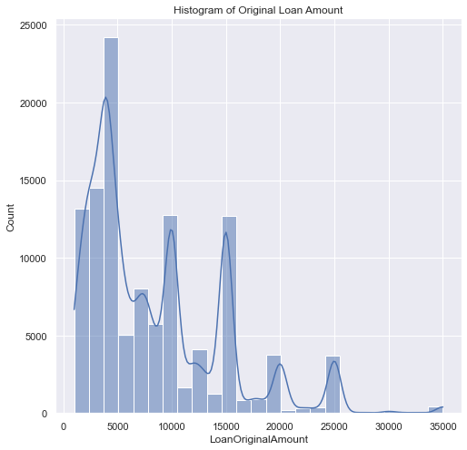

```python
histogram_plot('LoanOriginalAmount', 'Original Loan Amount')
```

> What is the dsitribution of the of loans according to the repayment term allowed for repayment

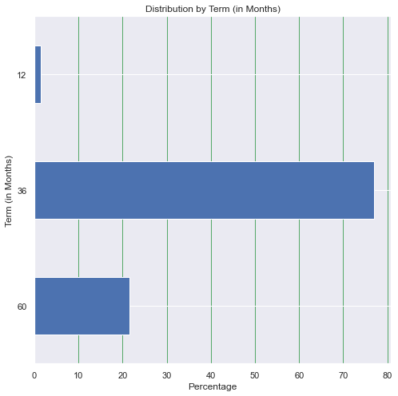

```python
barh_plot('Term', 'Term (in Months)')
```

- We can see most loan are slated to the paid in 3 years with the least slated for a year

> What is the dsitribution of the of the Investors?

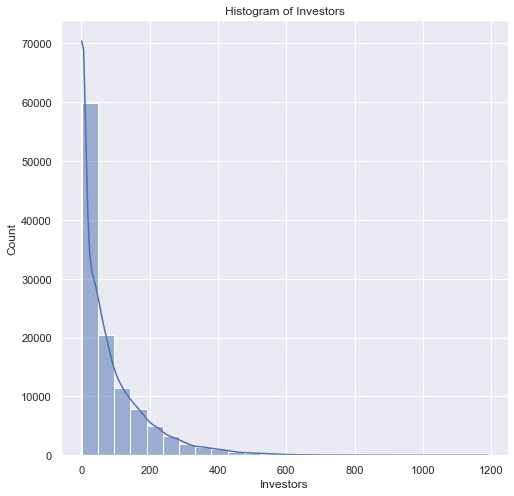

```python
histogram_plot('Investors', 'Investors')
```

> What is the dsitribution of the of the Bank card Utilization.

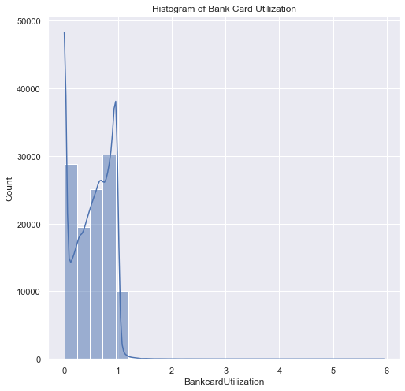

```python
histogram_plot('BankcardUtilization', 'Bank Card Utilization')
```

- We observe a nice variation of the Bank card utilization with little or no significant outliers.
- Most of the Bank card utilization appear to be between 0 and 1.

> What is the dsitribution of the Prosper Principal Borrowed?

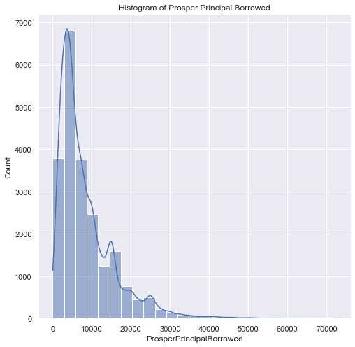

```python
histogram_plot('ProsperPrincipalBorrowed', 'Prosper Principal Borrowed')
```

- We observe a nice variation of the Proposed Principal borrowed with little or no significant outliers.
- Most of the Proposed Principal borrowed appear to be between 0 and 10 000.

> What is the dsitribution of the Debt To Income Ratio?

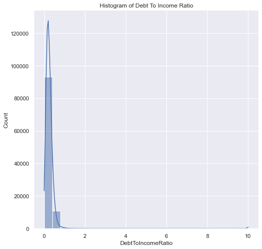

```python
histogram_plot('DebtToIncomeRatio', 'Debt To Income Ratio')
```

We see from above plot, the data is highly skewwed, so further examination is required.

```python
data['DebtToIncomeRatio'].describe()
```

```
count    105383.000000
mean          0.275947
std           0.551759
min           0.000000
25%           0.140000
50%           0.220000
75%           0.320000
max          10.010000
Name: DebtToIncomeRatio, dtype: float64
```

75% of the values are less than 0.5 .

We would the need to cut off the top 2%.

```python
low, high = data["DebtToIncomeRatio"].quantile([0.0, 0.98])
mask = data["DebtToIncomeRatio"].between(low, high)
data = data[mask]
```

See the resulting distribution

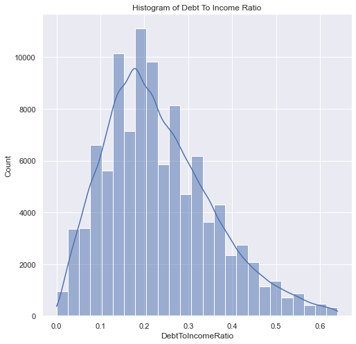

```python
histogram_plot('DebtToIncomeRatio', 'Debt To Income Ratio')
```

> What is the dsitribution of the Estimated Return?

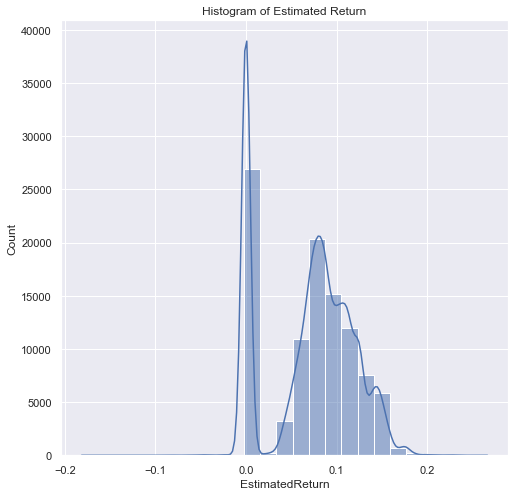

```python
histogram_plot('EstimatedReturn', 'Estimated Return')
```

- We observe a nice variation of the Estimated Return with little or no significant outliers.
- Most of the Estimated Return appear to be between 0 and 0.1.

> What is the dsitribution of the Prosper Principal Outstanding?

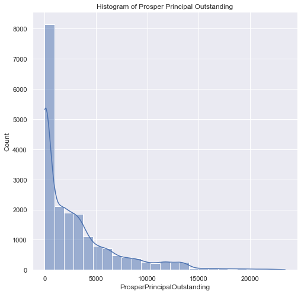

```python
histogram_plot('ProsperPrincipalOutstanding', 'Prosper Principal Outstanding')
```

We see from above plot, the data is highly skewed, so further examination is required.

```python
low, high = data["ProsperPrincipalOutstanding"].quantile([0.02, 0.98])
mask = data["ProsperPrincipalOutstanding"].between(low, high)
data = data[mask]
```

See the resulting distribution

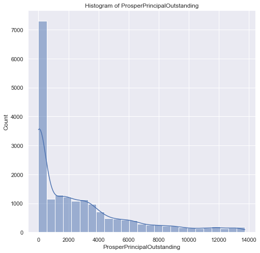

```python
histogram_plot('ProsperPrincipalOutstanding', 'ProsperPrincipalOutstanding')
```

> What is the dsitribution of the Stated Monthly Income?

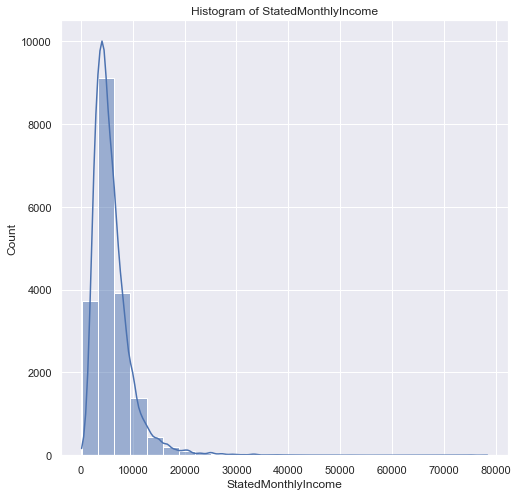

```python
histogram_plot('StatedMonthlyIncome', 'StatedMonthlyIncome')
```

We see from above plot, the data is highly skewed, so further examination is required.

```python
data['StatedMonthlyIncome'].describe()
```

```
count    19051.000000
mean      5959.713528
std       3917.690013
min        166.666667
25%       3559.000000
50%       5000.000000
75%       7166.666667
max      78364.416667
Name: StatedMonthlyIncome, dtype: float64
```

75% of the values are less than 7k .

We would the need to cut off the top and bottom 2%.

```python
low, high = data["StatedMonthlyIncome"].quantile([0.02, 0.98])
mask = data["StatedMonthlyIncome"].between(low, high)
data = data[mask]
```

See the resulting distribution

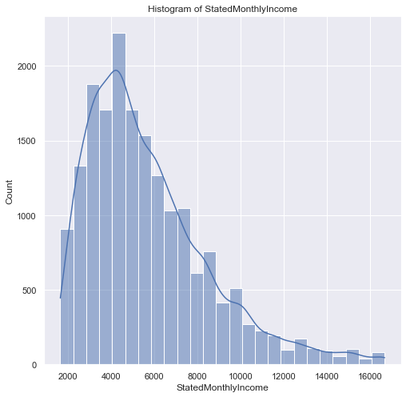

```python
histogram_plot('StatedMonthlyIncome', 'StatedMonthlyIncome')
```

> What is the dsitribution of the Employment Status ?

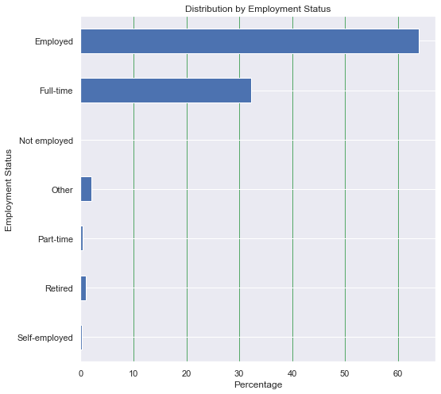

```python
barh_plot('EmploymentStatus', 'Employment Status')
```

Over 60% of the loans given were to individual employed

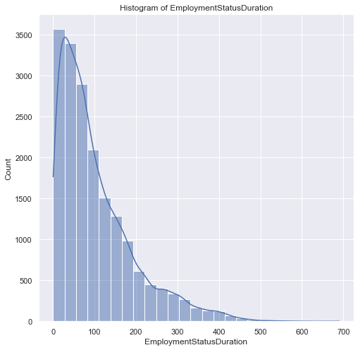

```python
histogram_plot('EmploymentStatusDuration', 'EmploymentStatusDuration')
```

We see from above plot, the data is highly skewwed, so further examination is required.

```python
data["EmploymentStatusDuration"].describe()
```

```
count    18370.000000
mean       102.582689
std         90.666922
min          0.000000
25%         36.000000
50%         76.000000
75%        144.000000
max        690.000000
Name: EmploymentStatusDuration, dtype: float64
```

75% of the values are less than 150 .

We would the need to cut off the top and bottom 2%.

```python
low, high = data["EmploymentStatusDuration"].quantile([0.02, 0.98])
mask = data["EmploymentStatusDuration"].between(low, high)
data = data[mask]
```

See the resulting distribution

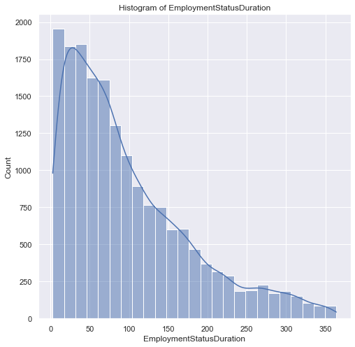

```python
histogram_plot('EmploymentStatusDuration', 'EmploymentStatusDuration')
```

> What is the dsitribution of the Income Range ?

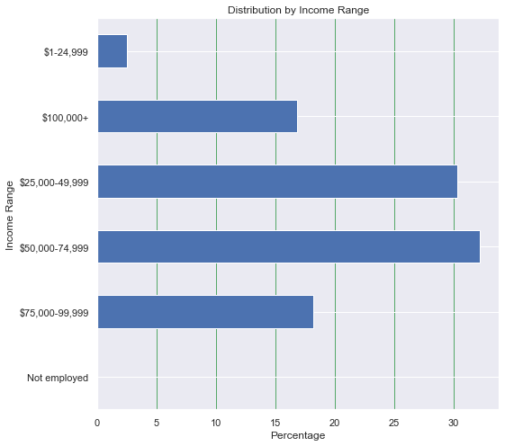

```python
barh_plot('IncomeRange', 'Income Range')
```

- Over 60% of the those that received loans fall within the income range of $ 25,000 to $75,000

> What is the dsitribution of the Loan Status ?

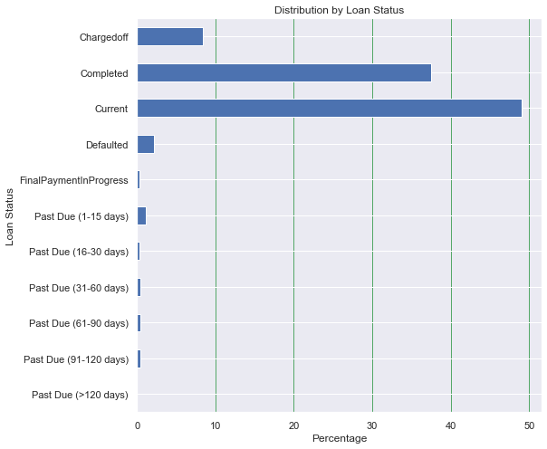

```python
barh_plot('LoanStatus', 'Loan Status')
```

- Most of the loan taken were either Charged off, complete or currently in payment
- The defaulted and those past their due date constituted a small chunk of data

> What is the dsitribution of the Is Borrower Homeowner.

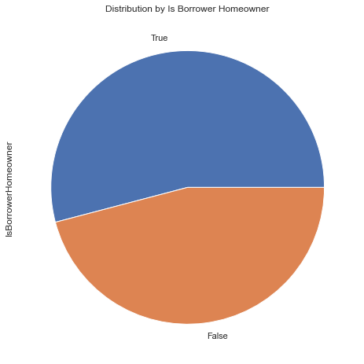

```python
pie_plot('IsBorrowerHomeowner', 'Is Borrower Homeowner')
```

- Most loan were take by home owners

> What is the dsitribution of the Lender Yield.

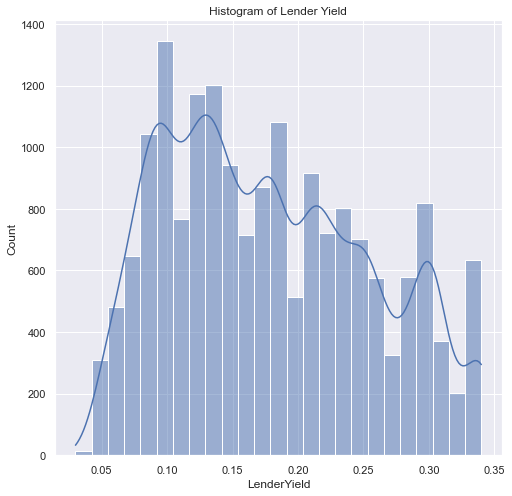

```python
histogram_plot('LenderYield', 'Lender Yield')
```

- It appeard to be nicely distributed

> What is the dsitribution of the Stated Monthly Income.

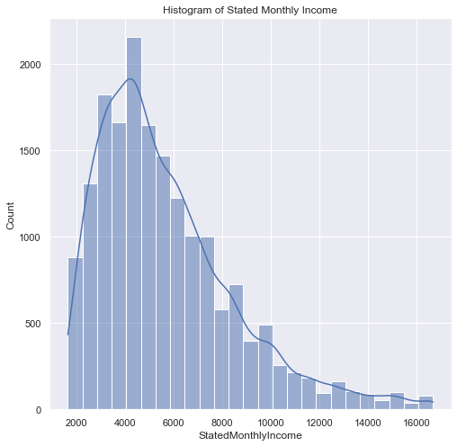

```python
histogram_plot('StatedMonthlyIncome', 'Stated Monthly Income')
```

- It appeard to be nicely distributed

> What is the dsitribution of the Borrower APR ?

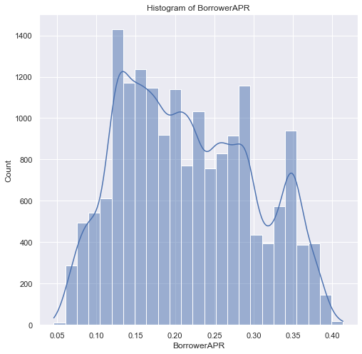

```python
histogram_plot('BorrowerAPR', 'BorrowerAPR')
```

- It appeard to be nicely distributed

## Bivariate Exploration

> In this section, investigate relationships between pairs of variables in your data.

> We begin by defining functions that would be helpful to us throughout this phase.

> > Function called **'scatter'** that will collect two variable (x, and y). It will plot scatter plot of thetwo variables.

```python
def scatter(x, y):
    sns.regplot(
        data = data,
        x = x,
        y = y,
        truncate=False, x_jitter=0.3,
        scatter_kws={'alpha':1/20}
        )
    plt.title(f'Scatter Plot of of {x} vs {y}')
```

> > Function called **'boxplot'** that will collect two variable (x, and y). It will plot box plot of the two variables.

```python
def boxplot(x,y):
    sns.boxplot(data=data,
               x= x,
               y= y
              )
    plt.title(f'Boxplot of {x} vs {y}')
```

> Examine the relationship between the Loan Original Amount and Income Range.

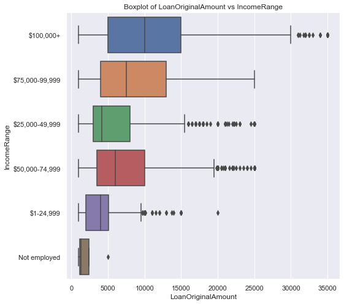

```python
boxplot('LoanOriginalAmount', 'IncomeRange')
```

- The Non employed had the lowest average loan given with those that earn more than 100K got highest loan.

> Examine the relationship between the Loan Original Amount and Investors.

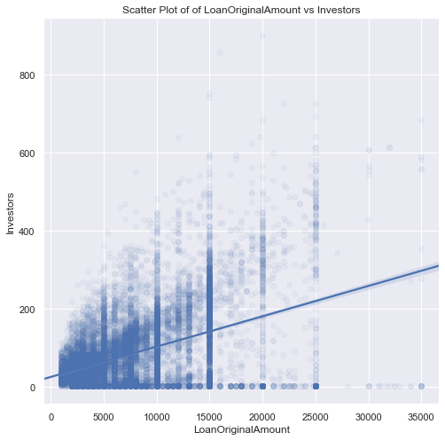

```python
scatter('LoanOriginalAmount', 'Investors')
```

- There exist a positve correlation between this two variables

> Examine the relationship between the Loan Original Amount and Term.

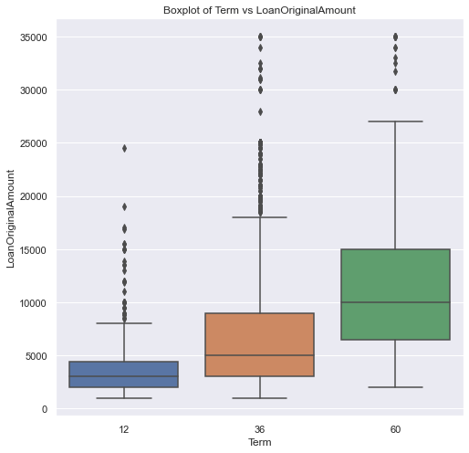

```python
boxplot('Term', 'LoanOriginalAmount')
```

- The more loan amount given the higher the timeframe for payment.

> Examine the relationship between the Loan Original Amount and Debt To Income Ratio.

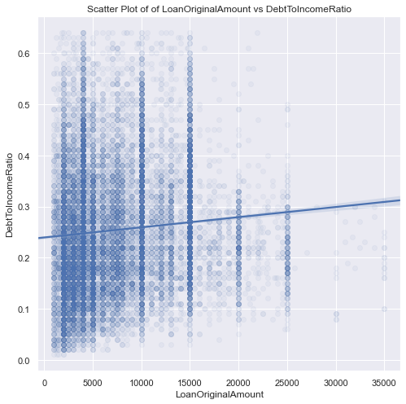

```python
scatter('LoanOriginalAmount', 'DebtToIncomeRatio')
```

- There exist a slight positve correlation between this two variables

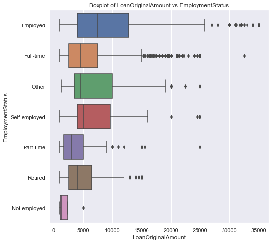

```python
boxplot('LoanOriginalAmount', 'EmploymentStatus')
```

- The Non employed had the lowest average loan given with those that earn more than are employed got highest loan.

> Examine the relationship between the Loan Original Amount and Monthly Loan Payment.

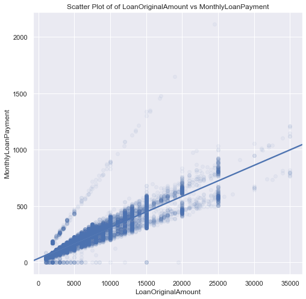

```python
scatter('LoanOriginalAmount','MonthlyLoanPayment')
```

- There exist a positve correlation between this two variables